# Literate programming using R Markdown

With code examples in R

MvO

2019-09-08

# 1 Introduction

This document shows some very basic examples of literate programming using R Markdown.

## 1.1 Literate programming

Literate programming = combining *live code* and *text* in one file. Special software is needed to “weave” such a file into a nicely readable document that combines the code-output with the text. The only weaving-software that we discuss here is **knitr**, which comes with **RStudio** (the ‘integrated development environment’, or IDE, for **R**). Use of RStudio is highly recommended: it helps not only with literate programming but also with using and testing any R-code.

So in our literate prgramming we combine code-chunks written in R with text. To allow knitr to do its magic (i.e. create pretty documents with nice layout etc.), we should follow some rules when writing the text-bits. We choose the rules of the simplest mark-up language, **markdown**. RStudio understands markdown documents.

Once we have created our code-text mixture, i.e. our markdown-file (with extension .Rmd), we want to use knitr to weave it into something nice. RStudio gives us the options of knitr-export to three different file-types: *HTML*, *pdf*, *Word*.

# 2 Using knitr

## 2.1 Setting global options

The following global options change nothing (they are the defaults):

```r
knitr::opts_chunk$set(echo=TRUE,results="asis")
```

If you only want the results from R-code-chunks to be shown in the final document, then choose echo=FALSE. Many such options can be set. One important one is cache=TRUE which stores the results of calculations in separate files, and loads them when you re-weave the file. That is useful when you have finished your work on the code-chunks but are busy editing the text-bits, because then the HTML-, pdf- or Word-document are created faster.

## 2.2 Fonts: italics and bold

You can write *text in italics* and **in boldface**.

## 2.3 Quotes

A quote is written by starting a line with the > symbol:

> Modellers never write proper documentation!

## 2.4 Link to a webpage

A link to a file or website looks like this: [Helophilus pendulus](https://picasaweb.google.com/109778459922622855546/AYearInNorway#5900928803315985026).

## 2.5 Math equations

Let’s write some mathematics:

> $\alpha^2+\beta^2=\gamma^2$.

So the “LaTeX-way” to write variable names with a subscript or superscript is: $x_2$ and $x^2$. But there is also a markdown way for the superscript: x<sup>2</sup>.

Let’s write some more:

“If r equals 2, then $r^2$ is 4. And $\pi*r^2$ is 12.5663706.”

Finally, here is a complicated equation:
$$J_\alpha(x) = \sum\limits_{m=0}^\infty \frac{(-1)^m}{m! \, \Gamma(m + \alpha + 1)}{\left({\frac{x}{2}}\right)}^{2 m + \alpha}$$

## 2.6 Examples of code-chunks

Now we’ll show some code-chunks. Each of them consists of a few lines of code in R. RStudio has a drop-down menu that allows you to easily navigate between the code-chunks in your file. The drop-down menu also shows the keyboard shortcuts. Two very useful ones are *Ctrl-Alt-C* for running the current code-chunk, and *Ctrl-Alt-R* for running all of them. If you run code-chunks in such a way, their output will go to the regular places, i.e. the console and the Plots-window. So that is different from weaving the file using knitr, which makes the outputs part of your new external HTML-, pdf- or Word-document. So using these Ctrl-Alt commands is good for testing your code before weaving.

### 2.6.1 R-code 1

Let’s have some text first. OK, now the code:

```r
set.seed(1)
x <- rnorm(100)
mean(x)
```

[1] 0.1088874

### 2.6.2 R-code 2

This time we use the same R-code but following option: results=“hide”:

```r
set.seed(1)
x <- rnorm(100)
mean(x)
```

That second bit of code was evaluated, but no results were shown in the final document.

### 2.6.3 R-code 3: inline

R-code does not have to be placed in code-chunks beginning and ending in ```. Code can also be used inline, as part of a regular text-sentence. In this example we do first use a code-chunk, but just to calculate the variables ‘time’ and ‘rand’. Thereafter the values of those variables can be included inline.

```r
time <- format(Sys.time(), "%a %b %d %X %Y")
rand <- rnorm(1)
```

The time is now Sun Sep 08 21:25:50 2019, and our random number of the day is: -0.6203667. Another example of an inline calculation is this: pi^2 is equal to 9.8696044.

### 2.6.4 R-code 4: Creating plots

Let’s first get some numbers to plot:

```r
x <- rnorm(50); y <- x + rnorm(50,sd=0.3)
```

Now we create a scatterplot of those numbers:

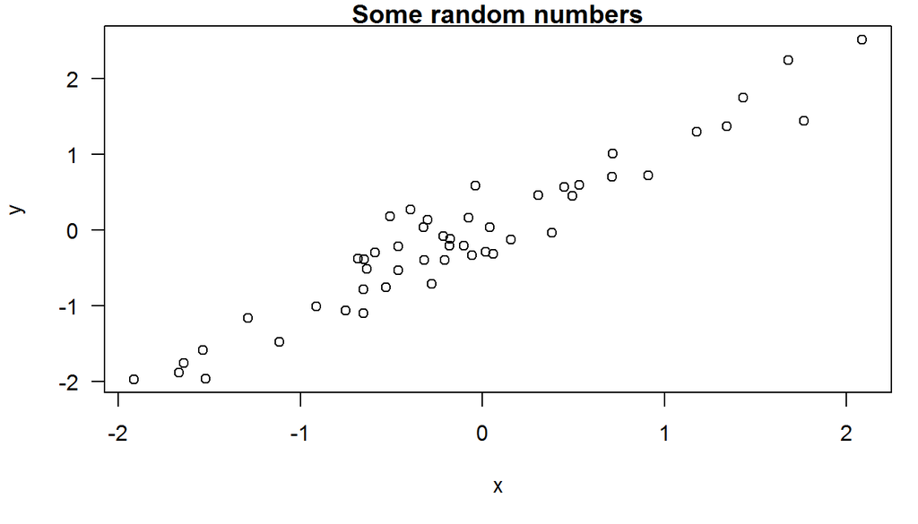

```r
par(mar=c(5,4,1,1),las=1)
plot(x,y,main="Some random numbers")
```

Note: if we export to an HTML-file, that plot will embedded! That is good (stand-alone file) and bad (big file).

### 2.6.5 R-code 5: Results from statistical analysis

We’ll get some data that come with R, and fit a linear model:

```r
library(datasets)
data(airquality)
fit <- lm(Ozone ~ Wind + Temp + Solar.R, data=airquality)
knitr::kable(anova(fit))
```

|  | Df | Sum Sq | Mean Sq | F value | Pr(>F) |
| --- | --- | --- | --- | --- | --- |
| Wind | 1 | 45694.237 | 45694.2369 | 101.85415 | 0.0000000 |
| Temp | 1 | 25118.710 | 25118.7095 | 55.99054 | 0.0000000 |
| Solar.R | 1 | 2986.173 | 2986.1731 | 6.65629 | 0.0112366 |
| Residuals | 107 | 48002.790 | 448.6242 | NA | NA |

## 2.7 Further reading

- [Karl Broman: “knitr in a knutshell: a minimal tutorial”](http://kbroman.org/knitr_knutshell/)
- [RStudio website: “R Markdown - Dynamic Documents for R”](http://rmarkdown.rstudio.com/)
- [Richard Layton: “Happy collaboration with Rmd to docx”](http://rmarkdown.rstudio.com/articles_docx.html)
- [Dean Attali: “Knitr’s best hidden gem: spin”](http://deanattali.com/2015/03/24/knitrs-best-hidden-gem-spin/)